# SL_Project_Part_B

1. Data Understanding and Preparation: A. Read both the Datasets ‘Data1’ and ‘Data 2’ as DataFrame and store them into two separate variables.

```python
import numpy as np
import pandas as pd
import matplotlib as plt
import seaborn as sns
%matplotlib inline
from sklearn.model_selection import train_test_split

from scipy.stats import zscore
import seaborn as sns
import matplotlib.pyplot as plt

df_1 = pd.read_csv('Part2+-+Data1.csv')
```

```python
df_2 = pd.read_csv('Part2+-Data2.csv')
```

B. Print shape and Column Names and DataTypes of both the Dataframes.

```python
df_1.shape
```

```
(5000, 8)
```

```python
df_1.columns
```

```
Index(['ID', 'Age', 'CustomerSince', 'HighestSpend', 'ZipCode', 'HiddenScore',
       'MonthlyAverageSpend', 'Level'],
      dtype='object')
```

```python
df_2.shape
```

```
(5000, 7)
```

```python
df_2.columns
```

```
Index(['ID', 'Mortgage', 'Security', 'FixedDepositAccount', 'InternetBanking',
       'CreditCard', 'LoanOnCard'],
      dtype='object')
```

C. Merge both the Dataframes on ‘ID’ feature to form a single DataFrame

```python
df = pd.merge(df_1, df_2, on="ID")
df.shape
```

```
(5000, 14)
```

```python
df.columns
```

```
Index(['ID', 'Age', 'CustomerSince', 'HighestSpend', 'ZipCode', 'HiddenScore',
       'MonthlyAverageSpend', 'Level', 'Mortgage', 'Security',
       'FixedDepositAccount', 'InternetBanking', 'CreditCard', 'LoanOnCard'],
      dtype='object')
```

```python
df.describe().transpose()
```

|  | count | mean | std | min | 25% | 50% | 75% | max |
| --- | --- | --- | --- | --- | --- | --- | --- | --- |
| ID | 5000.0 | 2500.500000 | 1443.520003 | 1.0 | 1250.75 | 2500.5 | 3750.25 | 5000.0 |
| Age | 5000.0 | 45.338400 | 11.463166 | 23.0 | 35.00 | 45.0 | 55.00 | 67.0 |
| CustomerSince | 5000.0 | 20.104600 | 11.467954 | -3.0 | 10.00 | 20.0 | 30.00 | 43.0 |
| HighestSpend | 5000.0 | 73.774200 | 46.033729 | 8.0 | 39.00 | 64.0 | 98.00 | 224.0 |
| ZipCode | 5000.0 | 93152.503000 | 2121.852197 | 9307.0 | 91911.00 | 93437.0 | 94608.00 | 96651.0 |
| HiddenScore | 5000.0 | 2.396400 | 1.147663 | 1.0 | 1.00 | 2.0 | 3.00 | 4.0 |
| MonthlyAverageSpend | 5000.0 | 1.937938 | 1.747659 | 0.0 | 0.70 | 1.5 | 2.50 | 10.0 |
| Level | 5000.0 | 1.881000 | 0.839869 | 1.0 | 1.00 | 2.0 | 3.00 | 3.0 |
| Mortgage | 5000.0 | 56.498800 | 101.713802 | 0.0 | 0.00 | 0.0 | 101.00 | 635.0 |
| Security | 5000.0 | 0.104400 | 0.305809 | 0.0 | 0.00 | 0.0 | 0.00 | 1.0 |
| FixedDepositAccount | 5000.0 | 0.060400 | 0.238250 | 0.0 | 0.00 | 0.0 | 0.00 | 1.0 |
| InternetBanking | 5000.0 | 0.596800 | 0.490589 | 0.0 | 0.00 | 1.0 | 1.00 | 1.0 |
| CreditCard | 5000.0 | 0.294000 | 0.455637 | 0.0 | 0.00 | 0.0 | 1.00 | 1.0 |
| LoanOnCard | 4980.0 | 0.096386 | 0.295149 | 0.0 | 0.00 | 0.0 | 0.00 | 1.0 |

D. Change Datatype of below features to ‘Object’.‘CreditCard’, ‘InternetBanking’, ‘FixedDepositAccount’, ‘Security’, ‘Level’, ‘HiddenScore’

```python
df.dtypes
```

```
ID                       int64
Age                      int64
CustomerSince            int64
HighestSpend             int64
ZipCode                  int64
HiddenScore              int64
MonthlyAverageSpend    float64
Level                    int64
Mortgage                 int64
Security                 int64
FixedDepositAccount      int64
InternetBanking          int64
CreditCard               int64
LoanOnCard             float64
dtype: object
```

```python
df.astype({'CreditCard': 'object'}).dtypes
```

```
ID                       int64
Age                      int64
CustomerSince            int64
HighestSpend             int64
ZipCode                  int64
HiddenScore              int64
MonthlyAverageSpend    float64
Level                    int64
Mortgage                 int64
Security                 int64
FixedDepositAccount      int64
InternetBanking          int64
CreditCard              object
LoanOnCard             float64
dtype: object
```

1. Data Exploration and Analysis: A. Visualize distribution of Target variable ‘LoanOnCard’ and clearly share insights.

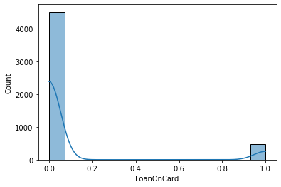

```python
sns.histplot(df['LoanOnCard'],kde = True)
```

The feature LoanOncard is a binary feature where it shows the strngth of people who have opted for loan on card tobe 1 and those who have not opted loaon on card is given the value 0.

B. Check the percentage of missing values and impute if required.

```python
null_percent = (df.isnull().sum())/len(df)
null_percent
```

```
ID                     0.000
Age                    0.000
CustomerSince          0.000
HighestSpend           0.000
ZipCode                0.000
HiddenScore            0.000
MonthlyAverageSpend    0.000
Level                  0.000
Mortgage               0.000
Security               0.000
FixedDepositAccount    0.000
InternetBanking        0.000
CreditCard             0.000
LoanOnCard             0.004
dtype: float64
```

```python
df['LoanOnCard'].fillna(0, inplace=True)
df['LoanOnCard']
```

```
0       0.0
1       0.0
2       0.0
3       0.0
4       0.0
       ...
4995    0.0
4996    0.0
4997    0.0
4998    0.0
4999    0.0
Name: LoanOnCard, Length: 5000, dtype: float64
```

C. Check for unexpected values in each categorical variable and impute with best suitable value

```python
#Checking for wrong entries like symbols -,?,#,*,etc.in categorical columns.
for col in df.columns:
    print('{} : {}'.format(col,df[col].unique()))
```

```
ID : [   1    2    3 ... 4998 4999 5000]
Age : [25 45 39 35 37 53 50 34 65 29 48 59 67 60 38 42 46 55 56 57 44 36 43 40
 30 31 51 32 61 41 28 49 47 62 58 54 33 27 66 24 52 26 64 63 23]
CustomerSince : [ 1 19 15  9  8 13 27 24 10 39  5 23 32 41 30 14 18 21 28 31 11 16 20 35
  6 25  7 12 26 37 17  2 36 29  3 22 -1 34  0 38 40 33  4 -2 42 -3 43]
HighestSpend : [ 49  34  11 100  45  29  72  22  81 180 105 114  40 112 130 193  21  25
  63  62  43 152  83 158  48 119  35  41  18  50 121  71 141  80  84  60
 132 104  52 194   8 131 190  44 139  93 188  39 125  32  20 115  69  85
 135  12 133  19  82 109  42  78  51 113 118  64 161  94  15  74  30  38
   9  92  61  73  70 149  98 128  31  58  54 124 163  24  79 134  23  13
 138 171 168  65  10 148 159 169 144 165  59  68  91 172  55 155  53  89
  28  75 170 120  99 111  33 129 122 150 195 110 101 191 140 153 173 174
  90 179 145 200 183 182  88 160 205 164  14 175 103 108 185 204 154 102
 192 202 162 142  95 184 181 143 123 178 198 201 203 189 151 199 224 218]
ZipCode : [91107 90089 94720 94112 91330 92121 91711 93943 93023 94710 90277 93106
```

[output cut: 74 more lines]

1. Data Preparation and model building: A. Split data into X and Y.

```python
X = df.drop('ID',axis=1)
X=X.drop('ZipCode',axis =1)

X=X.drop('LoanOnCard',axis=1)

y=df['LoanOnCard']
```

B. Split data into train and test. Keep 25% data reserved for testing.

```python
X_train, X_test, y_train, y_test = train_test_split(X, y, test_size=0.25, random_state=1)
```

C. Train a Supervised Learning Classification base model - Logistic Regression.

```python
X_train.head()
```

|  | Age | CustomerSince | HighestSpend | HiddenScore | MonthlyAverageSpend | Level | Mortgage | Security | FixedDepositAccount | InternetBanking | CreditCard |
| --- | --- | --- | --- | --- | --- | --- | --- | --- | --- | --- | --- |
| 3186 | 41 | 16 | 98 | 3 | 1.0 | 1 | 296 | 0 | 0 | 0 | 0 |
| 632 | 57 | 32 | 165 | 4 | 2.7 | 3 | 0 | 0 | 0 | 1 | 0 |
| 577 | 52 | 28 | 149 | 2 | 6.8 | 1 | 0 | 0 | 0 | 1 | 0 |
| 2406 | 31 | 7 | 10 | 1 | 0.5 | 3 | 81 | 0 | 0 | 1 | 0 |
| 4686 | 61 | 35 | 113 | 2 | 2.8 | 1 | 0 | 0 | 0 | 0 | 0 |

```python
print("{0:0.25f}% data is in training set".format((len(X_train)/len(df.index)) * 100))
print("{0:0.25f}% data is in test set".format((len(X_test)/len(df.index)) * 100))
```

```
75.0000000000000000000000000% data is in training set
25.0000000000000000000000000% data is in test set
```

```python
print("Original LoanOnCard True Values    : {0} ({1:0.25f}%)".format(len(df.loc[df['LoanOnCard'] == 1]), (len(df.loc[df['LoanOnCard'] == 1])/len(df.index)) * 100))
print("Original LoanOnCardFalse Values   : {0} ({1:0.25f}%)".format(len(df.loc[df['LoanOnCard'] == 0]), (len(df.loc[df['LoanOnCard'] == 0])/len(df.index)) * 100))
print("")
print("Training  LoanOnCard True Values    : {0} ({1:0.25f}%)".format(len(y_train[y_train[:] == 1]), (len(y_train[y_train[:] == 1])/len(y_train)) * 100))
print("Training  LoanOnCard False Values   : {0} ({1:0.25f}%)".format(len(y_train[y_train[:] == 0]), (len(y_train[y_train[:] == 0])/len(y_train)) * 100))
print("")
print("Test  LoanOnCard True Values        : {0} ({1:0.25f}%)".format(len(y_test[y_test[:] == 1]), (len(y_test[y_test[:] == 1])/len(y_test)) * 100))
print("Test LoanOnCard False Values       : {0} ({1:0.25f}%)".format(len(y_test[y_test[:] == 0]), (len(y_test[y_test[:] == 0])/len(y_test)) * 100))
print("")
```

```
Original LoanOnCard True Values    : 480 (9.5999999999999996447286321%)
Original LoanOnCardFalse Values   : 4520 (90.4000000000000056843418861%)

Training  LoanOnCard True Values    : 351 (9.3599999999999994315658114%)
Training  LoanOnCard False Values   : 3399 (90.6400000000000005684341886%)

Test  LoanOnCard True Values        : 129 (10.3200000000000002842170943%)
Test LoanOnCard False Values       : 1121 (89.6800000000000068212102633%)
```

```python
from sklearn import metrics

from sklearn.linear_model import LogisticRegression

# Fit the model on train
model = LogisticRegression(solver="liblinear")
model.fit(X_train, y_train)
#predict on test
y_predict = model.predict(X_test)


coef_df = pd.DataFrame(model.coef_)
coef_df['intercept'] = model.intercept_
print(coef_df)
```

```
          0         1         2         3         4         5         6  \
0 -0.408632  0.407558  0.050563  0.631637  0.140508  1.724797  0.000911

          7         8         9        10  intercept
0 -0.896506  3.148388 -0.589187 -0.914167  -2.503455
```

```python
log_reg_model_score = model.score(X_test, y_test)
print(log_reg_model_score)
```

```
0.9448
```

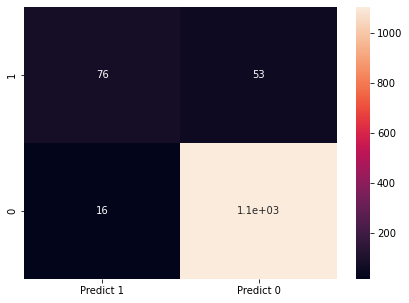

```python
cm=metrics.confusion_matrix(y_test, y_predict, labels=[1, 0])

df_cm = pd.DataFrame(cm, index = [i for i in ["1","0"]],
                  columns = [i for i in ["Predict 1","Predict 0"]])
plt.figure(figsize = (7,5))
sns.heatmap(df_cm, annot=True)
```

```python
from sklearn.metrics import classification_report

print(classification_report(y_test, y_predict, labels=[1, 0]))
```

```
              precision    recall  f1-score   support

           1       0.83      0.59      0.69       129
           0       0.95      0.99      0.97      1121

    accuracy                           0.94      1250
   macro avg       0.89      0.79      0.83      1250
weighted avg       0.94      0.94      0.94      1250
```

```python
df.groupby("LoanOnCard").agg({'LoanOnCard': 'count'})
```

| LoanOnCard | LoanOnCard |
| --- | --- |
| 0.0 | 4520 |
| 1.0 | 480 |

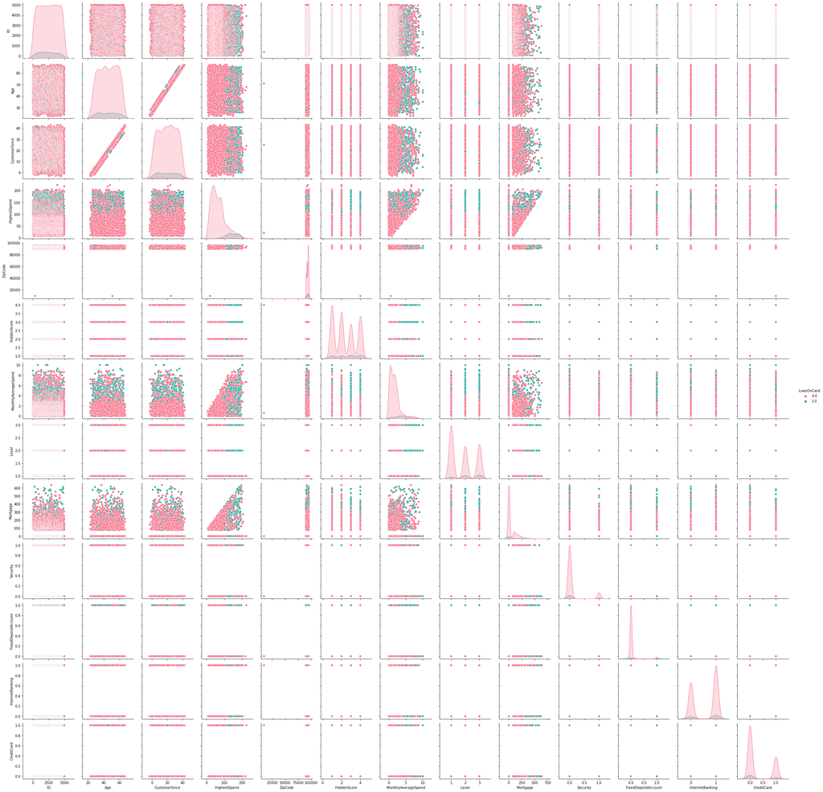

```python
sns.pairplot(df, hue="LoanOnCard", palette="husl")
```

```python
#Say output is class A : 20% and class B : 80%
df.corr()
```

|  | ID | Age | CustomerSince | HighestSpend | ZipCode | HiddenScore | MonthlyAverageSpend | Level | Mortgage | Security | FixedDepositAccount | InternetBanking | CreditCard | LoanOnCard |
| --- | --- | --- | --- | --- | --- | --- | --- | --- | --- | --- | --- | --- | --- | --- |
| ID | 1.000000 | -0.008473 | -0.008326 | -0.017695 | 0.013432 | -0.016797 | -0.024675 | 0.021463 | -0.013920 | -0.016972 | -0.006909 | -0.002528 | 0.017028 | -0.024801 |
| Age | -0.008473 | 1.000000 | 0.994215 | -0.055269 | -0.029216 | -0.046418 | -0.052012 | 0.041334 | -0.012539 | -0.000436 | 0.008043 | 0.013702 | 0.007681 | -0.007726 |
| CustomerSince | -0.008326 | 0.994215 | 1.000000 | -0.046574 | -0.028626 | -0.052563 | -0.050077 | 0.013152 | -0.010582 | -0.001232 | 0.010353 | 0.013898 | 0.008967 | -0.007413 |
| HighestSpend | -0.017695 | -0.055269 | -0.046574 | 1.000000 | -0.016410 | -0.157501 | 0.645984 | -0.187524 | 0.206806 | -0.002616 | 0.169738 | 0.014206 | -0.002385 | 0.502462 |
| ZipCode | 0.013432 | -0.029216 | -0.028626 | -0.016410 | 1.000000 | 0.011778 | -0.004061 | -0.017377 | 0.007383 | 0.004704 | 0.019972 | 0.016990 | 0.007691 | 0.000107 |
| HiddenScore | -0.016797 | -0.046418 | -0.052563 | -0.157501 | 0.011778 | 1.000000 | -0.109275 | 0.064929 | -0.020445 | 0.019994 | 0.014110 | 0.010354 | 0.011588 | 0.061367 |
| MonthlyAverageSpend | -0.024675 | -0.052012 | -0.050077 | 0.645984 | -0.004061 | -0.109275 | 1.000000 | -0.136124 | 0.109905 | 0.015086 | 0.136534 | -0.003611 | -0.006689 | 0.366889 |
| Level | 0.021463 | 0.041334 | 0.013152 | -0.187524 | -0.017377 | 0.064929 | -0.136124 | 1.000000 | -0.033327 | -0.010812 | 0.013934 | -0.015004 | -0.011014 | 0.136722 |
| Mortgage | -0.013920 | -0.012539 | -0.010582 | 0.206806 | 0.007383 | -0.020445 | 0.109905 | -0.033327 | 1.000000 | -0.005411 | 0.089311 | -0.005995 | -0.007231 | 0.142095 |
| Security | -0.016972 | -0.000436 | -0.001232 | -0.002616 | 0.004704 | 0.019994 | 0.015086 | -0.010812 | -0.005411 | 1.000000 | 0.317034 | 0.012627 | -0.015028 | 0.021954 |
| FixedDepositAccount | -0.006909 | 0.008043 | 0.010353 | 0.169738 | 0.019972 | 0.014110 | 0.136534 | 0.013934 | 0.089311 | 0.317034 | 1.000000 | 0.175880 | 0.278644 | 0.316355 |
| InternetBanking | -0.002528 | 0.013702 | 0.013898 | 0.014206 | 0.016990 | 0.010354 | -0.003611 | -0.015004 | -0.005995 | 0.012627 | 0.175880 | 1.000000 | 0.004210 | 0.006278 |
| CreditCard | 0.017028 | 0.007681 | 0.008967 | -0.002385 | 0.007691 | 0.011588 | -0.006689 | -0.011014 | -0.007231 | -0.015028 | 0.278644 | 0.004210 | 1.000000 | 0.002802 |
| LoanOnCard | -0.024801 | -0.007726 | -0.007413 | 0.502462 | 0.000107 | 0.061367 | 0.366889 | 0.136722 | 0.142095 | 0.021954 | 0.316355 | 0.006278 | 0.002802 | 1.000000 |

```python
count_class_0,count_class_1 = df.LoanOnCard.value_counts()
df_class_0 = df[df['LoanOnCard'] == 0]
df_class_1 = df[df['LoanOnCard'] == 1]
```

```python
count_class_0,count_class_1
```

```
(4520, 480)
```

```python
df_class_0.shape
```

```
(4520, 14)
```

```python
df_class_1.shape
```

```
(480, 14)
```

```python
df_class_0_under =df_class_0.sample(count_class_1)
df_test_under = pd.concat([df_class_0_under,df_class_1],axis = 0)
print(df_test_under.LoanOnCard.value_counts())
```

```
0.0    480
1.0    480
Name: LoanOnCard, dtype: int64
```

```python
X1 = df_test_under.drop('LoanOnCard',axis = 'columns')
y1 = df_test_under['LoanOnCard']
```

```python
from sklearn.model_selection import train_test_split
X1_train, X1_test, y1_train, y1_test = train_test_split(X1,y1, test_size =0.2 ,random_state = 15,stratify = y1)
```

```python
y1_train.value_counts()
```

```
1.0    384
0.0    384
Name: LoanOnCard, dtype: int64
```

Again train the same previous model on balanced data.

```python
from sklearn.linear_model import LogisticRegression

# Fit the model on train
model = LogisticRegression(solver="liblinear")
model.fit(X1_train, y1_train)
#predict on test
y1_predict = model.predict(X1_test)


coef_df = pd.DataFrame(model.coef_)
coef_df['intercept'] = model.intercept_
print(coef_df)
```

```
          0         1         2         3         4         5         6  \
0 -0.000029 -0.122771  0.114915  0.050758 -0.000062  0.419191  0.186462

          7         8         9        10        11        12  intercept
0  1.139026  0.000571 -0.209654  2.325845 -0.565666 -0.229294  -0.086967
```

```python
log_reg_score = model.score(X1_test, y1_test)
print(log_reg_score)
```

```
0.9479166666666666
```

```python
from sklearn.metrics import classification_report

print(classification_report(y1_test, y1_predict, labels=[1, 0]))
```

```
              precision    recall  f1-score   support

           1       0.95      0.95      0.95        96
           0       0.95      0.95      0.95        96

    accuracy                           0.95       192
   macro avg       0.95      0.95      0.95       192
weighted avg       0.95      0.95      0.95       192
```

1. Performance Improvement: A. Train a base model each for SVM, KNN

```python
#knn model
X = df.drop('ID',axis=1)
X=X.drop('ZipCode',axis =1)

X=X.drop('LoanOnCard',axis=1)

y=df['LoanOnCard']
XScaled  = X.apply(zscore)  # convert all attributes to Z scale
XScaled.describe()
```

|  | Age | CustomerSince | HighestSpend | HiddenScore | MonthlyAverageSpend | Level | Mortgage | Security | FixedDepositAccount | InternetBanking | CreditCard |
| --- | --- | --- | --- | --- | --- | --- | --- | --- | --- | --- | --- |
| count | 5.000000e+03 | 5.000000e+03 | 5.000000e+03 | 5.000000e+03 | 5.000000e+03 | 5.000000e+03 | 5.000000e+03 | 5.000000e+03 | 5.000000e+03 | 5.000000e+03 | 5.000000e+03 |
| mean | 2.478018e-17 | -1.693312e-16 | 1.939449e-16 | 7.850609e-16 | -2.078338e-17 | -6.315837e-16 | 2.810197e-16 | 5.092149e-16 | 4.426903e-16 | 2.986500e-16 | -3.697931e-16 |
| std | 1.000100e+00 | 1.000100e+00 | 1.000100e+00 | 1.000100e+00 | 1.000100e+00 | 1.000100e+00 | 1.000100e+00 | 1.000100e+00 | 1.000100e+00 | 1.000100e+00 | 1.000100e+00 |
| min | -1.948906e+00 | -2.014911e+00 | -1.428969e+00 | -1.216855e+00 | -1.108987e+00 | -1.049078e+00 | -5.555239e-01 | -3.414233e-01 | -2.535403e-01 | -1.216618e+00 | -6.453143e-01 |
| 25% | -9.019702e-01 | -8.812043e-01 | -7.554825e-01 | -1.216855e+00 | -7.084116e-01 | -1.049078e+00 | -5.555239e-01 | -3.414233e-01 | -2.535403e-01 | -1.216618e+00 | -6.453143e-01 |
| 50% | -2.952359e-02 | -9.121982e-03 | -2.123482e-01 | -3.454321e-01 | -2.506106e-01 | 1.417029e-01 | -5.555239e-01 | -3.414233e-01 | -2.535403e-01 | 8.219509e-01 | -6.453143e-01 |
| 75% | 8.429230e-01 | 8.629604e-01 | 5.263146e-01 | 5.259909e-01 | 3.216407e-01 | 1.332484e+00 | 4.375576e-01 | -3.414233e-01 | -2.535403e-01 | 8.219509e-01 | 1.549632e+00 |
| max | 1.889859e+00 | 1.996667e+00 | 3.263712e+00 | 1.397414e+00 | 4.613525e+00 | 1.332484e+00 | 5.688108e+00 | 2.928915e+00 | 3.944146e+00 | 8.219509e-01 | 1.549632e+00 |

```python
X_train, X_test, y_train, y_test = train_test_split(XScaled, y, test_size=0.30, random_state=1)
```

```python
from sklearn.neighbors import KNeighborsClassifier
from scipy.stats import zscore
knn = KNeighborsClassifier(n_neighbors = 5 , weights ='distance')
```

```python
# Call Nearest Neighbour algorithm

knn.fit(X_train, y_train)
```

```
KNeighborsClassifier(weights='distance')
```

```python
predicted_labels = knn.predict(X_test)
knn.score(X_test, y_test)
```

```
0.954
```

```python
# calculate accuracy measures and confusion matrix
from sklearn.metrics import confusion_matrix

print("Confusion Matrix")

cm = confusion_matrix(y_test,predicted_labels)
cm
```

```
Confusion Matrix
```

```
array([[1344,    7],
       [  62,   87]], dtype=int64)
```

```python
from sklearn.metrics import classification_report
target_names = ['0', '1']
print(classification_report(y_test, predicted_labels, target_names=target_names))
```

```
              precision    recall  f1-score   support

           0       0.96      0.99      0.97      1351
           1       0.93      0.58      0.72       149

    accuracy                           0.95      1500
   macro avg       0.94      0.79      0.85      1500
weighted avg       0.95      0.95      0.95      1500
```

```python
#Tune parameters for knn model wherever required and finalize a model
```

```python
myList = list(range(1,50))
neighbors = list(filter(lambda x: x % 2 != 0, myList))
```

```python
# perform accuracy metrics for values from 1,3,5....19
from sklearn.metrics import accuracy_score
ac_scores = []
for k in neighbors:
    knn = KNeighborsClassifier(n_neighbors=k)
    knn.fit(X_train, y_train)
    # predict the response
    y_pred = knn.predict(X_test)
    # evaluate accuracy
    scores = accuracy_score(y_test, y_pred)
    ac_scores.append(scores)
# changing to misclassification error
MSE = [1 - x for x in ac_scores]

# determining best k
optimal_k = neighbors[MSE.index(min(MSE))]
print("The optimal number of neighbors is %d" % optimal_k)
```

```
The optimal number of neighbors is 3
```

```python
knn = KNeighborsClassifier(n_neighbors = 3)

# fitting the model
knn.fit(X_train, y_train)

# predict the response
y_pred = knn.predict(X_test)

# evaluate accuracy
print(accuracy_score(y_test, y_pred))
```

```
0.9553333333333334
```

```python
#performance metrics after tuning knn parameters

print(classification_report(y_test, y_pred,labels = [1,0]))
```

```
              precision    recall  f1-score   support

           1       0.90      0.62      0.73       149
           0       0.96      0.99      0.98      1351

    accuracy                           0.96      1500
   macro avg       0.93      0.81      0.85      1500
weighted avg       0.95      0.96      0.95      1500
```

The performance metrics of the knn model before and after tuning shows no considerable differences in the case of f1 scores and precision but recall has slightly improved.

SVM

```python
X_train, X_test, y_train, y_test = train_test_split(XScaled, y, test_size=0.2, random_state=42)

from sklearn.svm import SVC
model_svm = SVC(kernel='rbf',C=0.25)
clf_svm = model_svm.fit(X_train,y_train)
y_svm = model_svm.predict(X_test)

from sklearn.metrics import accuracy_score
print('Accuracy of SVM: ', accuracy_score(y_svm, y_test))
```

```
Accuracy of SVM:  0.965
```

```python
#Tuning of SVM Classification Model
```

```python
#C. Print evaluation metrics for final model.
print(classification_report(y_test, y_svm, labels=[1, 0]))
```

```
              precision    recall  f1-score   support

           1       0.96      0.70      0.81       105
           0       0.97      1.00      0.98       895

    accuracy                           0.96      1000
   macro avg       0.96      0.85      0.89      1000
weighted avg       0.96      0.96      0.96      1000
```

```python
from sklearn.model_selection import GridSearchCV
param_grid = {'C': [0.1,0.25,1, 10, 100], 'gamma': [1,0.1,0.01,0.001],'kernel': ['rbf', 'poly', 'sigmoid']}
grid = GridSearchCV(SVC(),param_grid,refit=True,verbose=2)
grid.fit(X_train,y_train)
print(grid.best_estimator_)
```

[output not shown]

[output cut: 247 more lines]

[output not shown]

```python
grid_predictions = grid.predict(X_test)
print(confusion_matrix(y_test,grid_predictions))
print(classification_report(y_test,grid_predictions))
```

```
[[891   4]
 [ 12  93]]
              precision    recall  f1-score   support

         0.0       0.99      1.00      0.99       895
         1.0       0.96      0.89      0.92       105

    accuracy                           0.98      1000
   macro avg       0.97      0.94      0.96      1000
weighted avg       0.98      0.98      0.98      1000
```

D. Share improvement achieved from base model to final model

In order to improve the model accuracy, there are several parameters need to be tuned. Three major parameters including:

Kernels: The main function of the kernel is to take low dimensional input space and transform it into a higher-dimensional space. It is mostly useful in non-linear separation problem.

1. C (Regularisation): C is the penalty parameter, which represents misclassification or error term. The misclassification or error term tells the SVM optimisation how much error is bearable. This is how you can control the trade-off between decision boundary and misclassification term.
2. Gamma: It defines how far influences the calculation of plausible line of separation. when gamma is higher, nearby points will have high influence; low gamma means far away points also be considered to get the decision boundary.

After performing the tuning of gamma and C and kernels the f1 score both classes has improved from the earlier value 0.81 and 0.98 which seems imbalanced to 0.99 and 0.92. This is distinct improvement from the base SVM model.